# 使用R拟合分布

brightbird

2015年9月18日

### 零.几个常用的概率函数介绍

这里，参考R语言实战，以及[Fitting Distribution with R]的附录。

### 一.认识各种分布的形态

#### 1.1 连续型随机变量的分布

##### 1.1.1 正态分布

正态分布$N(\mu, \sigma^2)$的密度函数： $f(y,\mu,\sigma^2)=\frac{1}{\sqrt{2\pi\sigma^2}}exp\left[-\frac{1}{2}(\frac{y-\mu}{\sigma})^2\right]$

正态分布的形态如图。

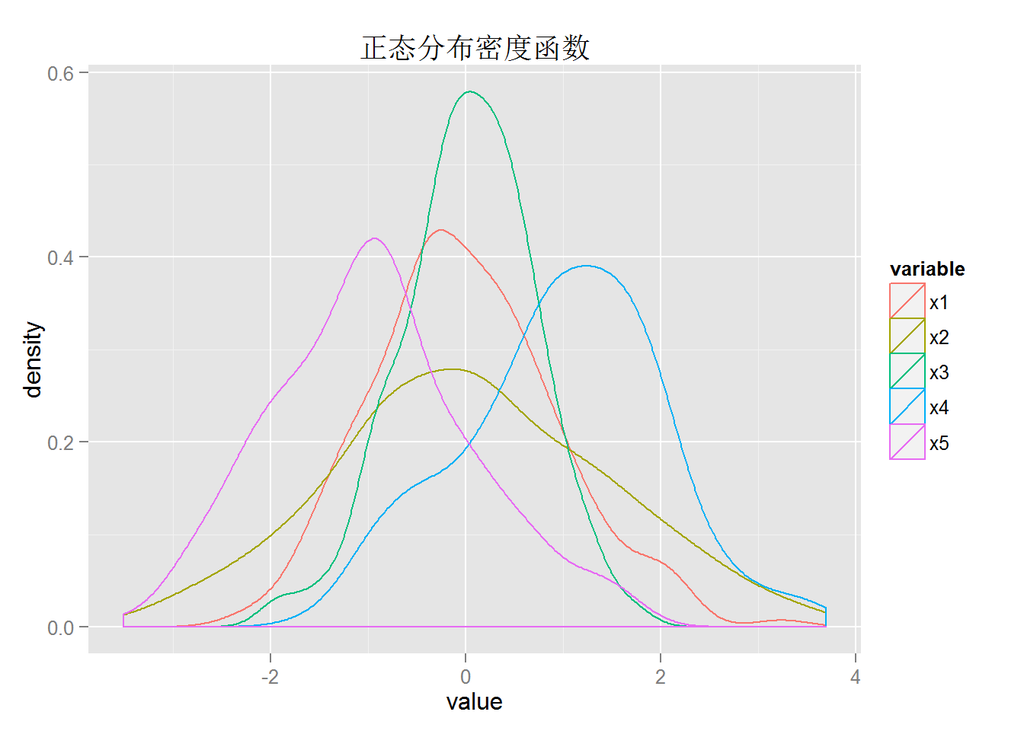

```r
library(ggplot2)
library(reshape2)
library(dplyr)
#产生分布数据
set.seed(123)
data_norm<-data.frame(x1 = rnorm(n = 200, m = 0, sd = 1),
                      x2 = rnorm(n = 200, m = 0, sd = sqrt(2)),
                      x3 = rnorm(n = 200, m = 0, sd = sqrt(0.5)),
                      x4 = rnorm(n = 200, m = 1, sd = 1),
                      x5 = rnorm(n = 200, m = -1, sd =1)
)
data_norm_long<-melt(data_norm)
ggplot(data = data_norm_long, aes(x = value, colour = variable))+
  geom_density()+
  ggtitle("正态分布密度函数")
```

正态分布可以衍生出如下的分布。

##### 1.1.2 卡方分布

若$Z_{i}\sim\ i.i.d N(0, 1)$,则有  
$X^2 = \sum_{i = 1}^{n}Z_{i}^2\sim\ \chi^2(n)$

```r
set.seed(123)
data_chisq<-data.frame(x1 = rchisq(200, 10, ncp = 0),
                       x2 = rchisq(200, 50, ncp =0),
                       x3 = rchisq(200, 100, ncp = 0))
data_chisq_long<-melt(data_chisq)
```

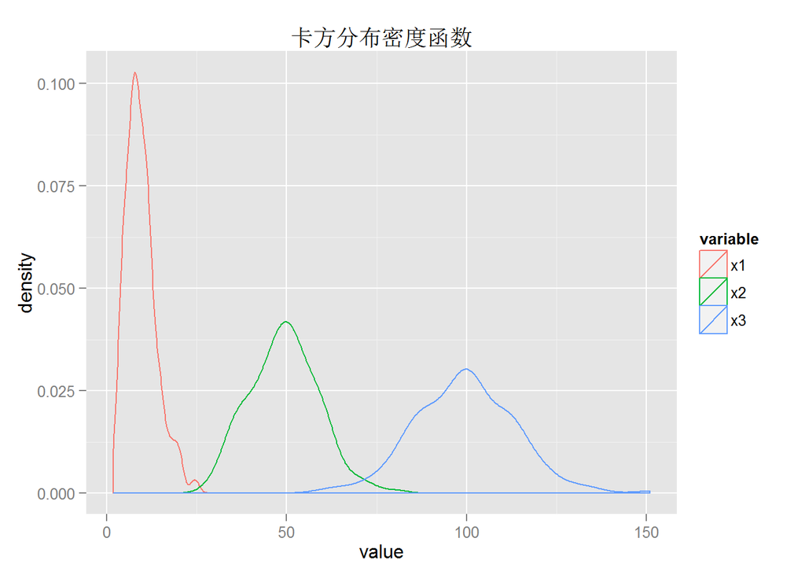

```r
ggplot(data = data_chisq_long, aes(x = value, colour = variable))+
  geom_density()+
  ggtitle("卡方分布密度函数")
```

##### 1.1.3 $t-$分布

若$Z\sim\ N(0, 1)$,$X^2\sim\ \chi^2(n)$，并且$Z$和$X^2$独立，则有 $T = \frac{Z}{(X^2/n)^2}\sim\ t(n)$

```r
set.seed(123)
data_t<-data.frame(x1 = rt(200, 10, ncp = 0),
                       x2 = rt(200, 50, ncp =0),
                       x3 = rt(200, 100, ncp = 0))
data_t_long<-melt(data_t)
```

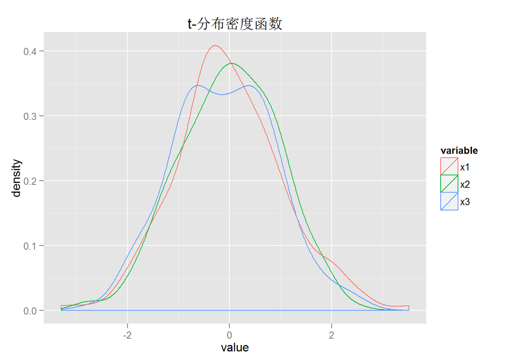

```r
ggplot(data = data_t_long, aes(x = value, colour = variable))+
  geom_density()+
  ggtitle("t-分布密度函数")
```

##### 1.1.4 $F-$分布

若$X_{1}^2\sim\chi^2(n)$,$X_{2}^2\sim\chi^2(m)$,并且$X_{1}$和$X_{2}$相互独立，则有 $F = \frac{X_1^2}{n}/\frac{X_2^2}{m}\sim\ F(n, m)$

```r
set.seed(123)
data_f<-data.frame(x1 = rf(200,df1 = 10, df2 = 10, ncp = 0),
                       x2 = rf(200,df1 = 5, df2 = 3, ncp =0),
                       x3 = rf(200, df1 = 3, df2 = 5, ncp = 0))
data_f_long<-melt(data_f)
```

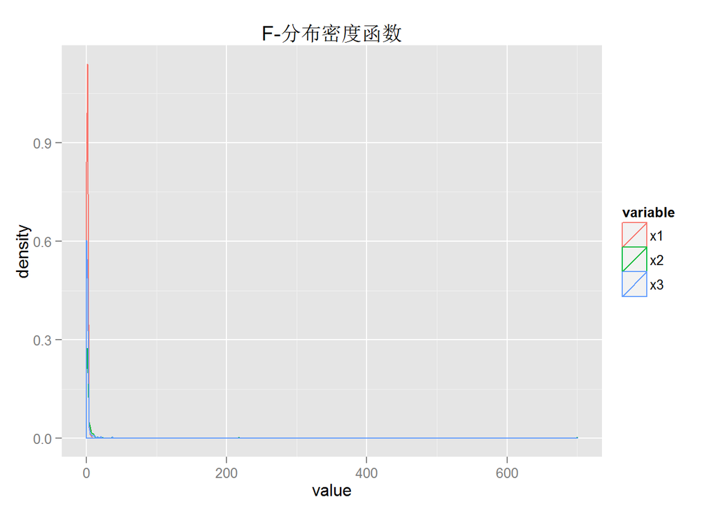

```r
ggplot(data = data_f_long, aes(x = value, colour = variable))+
  geom_density()+
  ggtitle("F-分布密度函数")
```

##### 1.1.5 $Wishart$分布

$Wishart$分布是$\chi^2$分布在$p$维正态情况下的推广。这里对多维情况暂不展开介绍。

#### 1.2 离散型随机变量的分布

##### 1.2.1 伯努利($Bernoulli$)分布

伯努利分布记为$Bernoulli(p)$，只有0和1两种取值。概率测度函数如下： $f_{X}(x) = p^x(1-p)^x\ for\ x = 0, 1$

##### 1.2.2 二项($Binomial$)分布

二项分布$B(n,p)$的可能取值范围为${0,1,...,n}$。其概率测度函数如下： $f_{X}(x) = \binom{n}{x}p^x(1-p)^x,\ x = 0,1,...,n.$

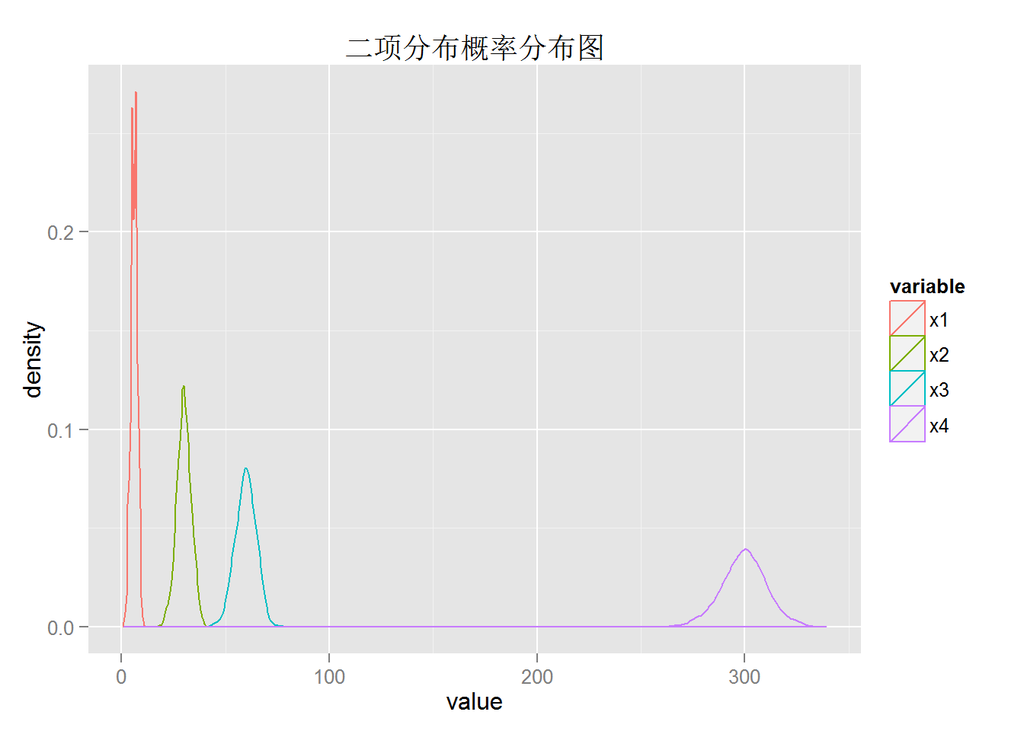

```r
set.seed(123)
data_binom<-data.frame(x1 = rbinom(n = 1000, size = 10, prob = 0.6),
                      x2 = rbinom(n = 1000, size = 50, prob = 0.6),
                      x3 = rbinom(n = 1000, size = 100, prob = 0.6),
                      x4 = rbinom(n = 1000, size = 500, prob = 0.6))

data_binom_long<-melt(data_binom)
ggplot(data = data_binom_long, aes(x = value, colour = variable))+
  geom_density()+
  ggtitle("二项分布概率分布图")
```

##### 1.2.3 负二项($Negative Binomial$)分布

负二项分布。

##### 1.2.4 几何($Geometric$)分布

##### 1.2.5 泊松($Poission$)分布

#### 1.3 指数分布族及其相互联系

##### 1.3.1 指数分布族

[广义线性模型导论3rd edition,p58]

##### 1.3.2 指数分布

##### 1.3.3 Weibull分布

##### 1.3.4 Beta分布

##### 1.3.5 Gama分布

##### 1.3.6 双指数($Double Exponential$)分布

#### 1.4 其他分布

##### 1.4.1 均匀($Uniform$)分布

##### 1.4.2 柯西($Cauchy$)分布

##### 1.4.3 对数正态($Lognormal$)分布

#### 1.5 可视化探索的步骤举例

首先，通过直方图，经验累积分布形态等来观察数据的分布形态。

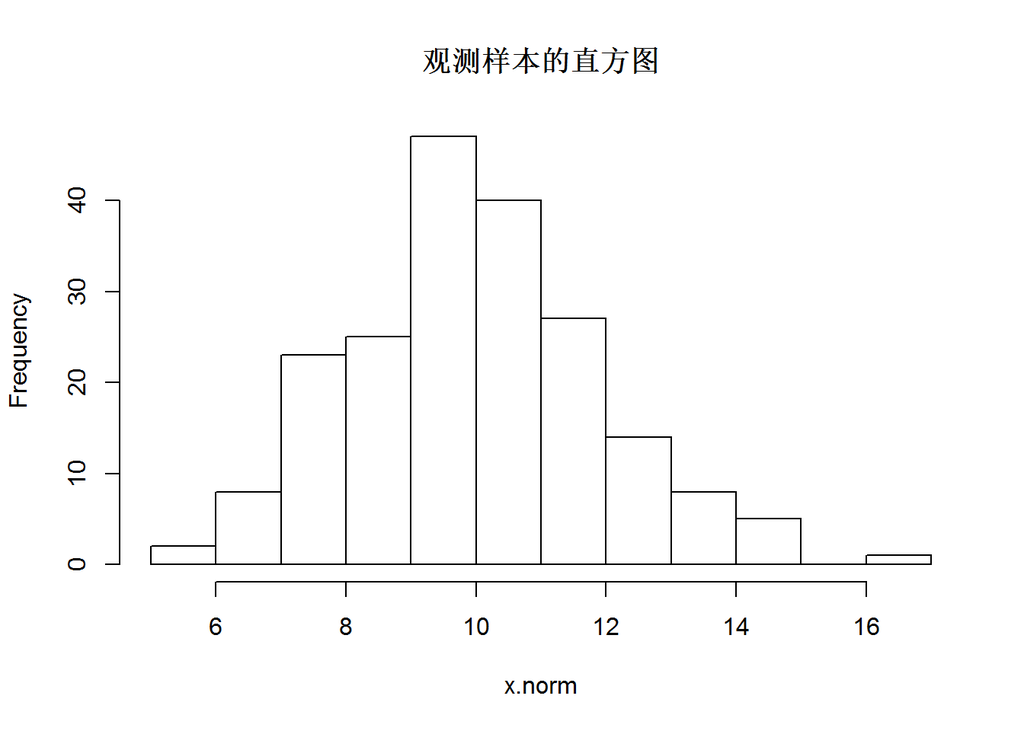

```r
#产生一组服从N(10,2)分布的随机数
set.seed(123)
x.norm<-rnorm(n = 200, m =10, sd = 2)
#绘制直方图
hist(x.norm, main = "观测样本的直方图")
```

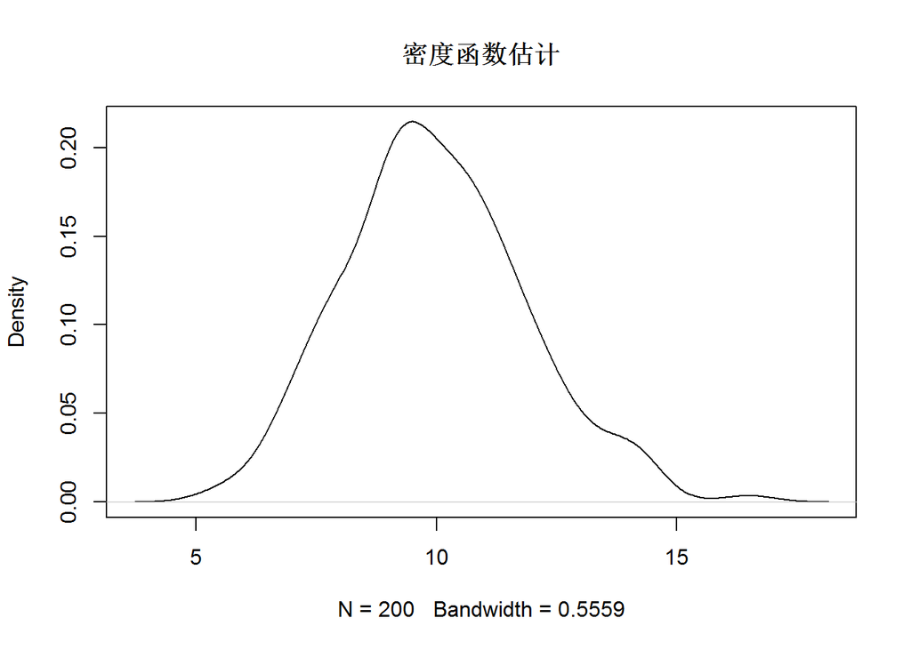

```r
#拟合密度曲线
plot(density(x.norm), main = "密度函数估计")
```

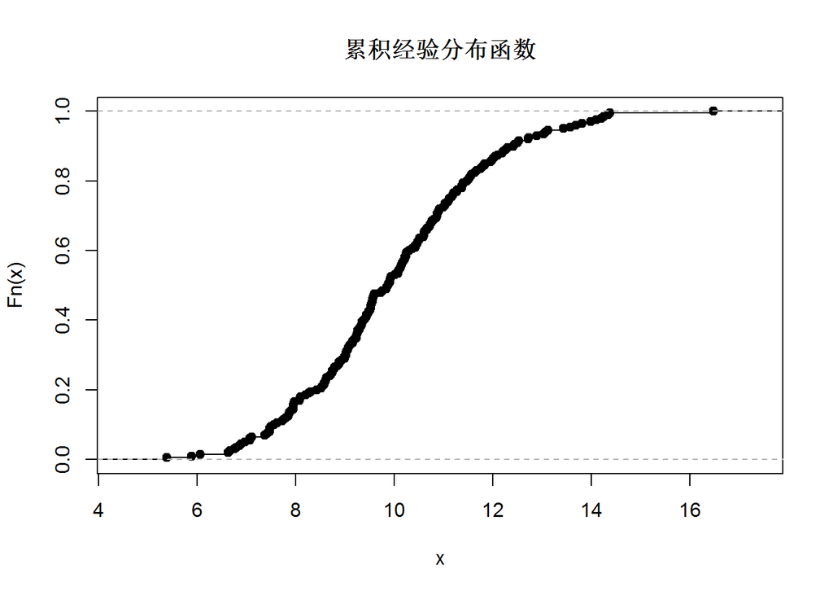

```r
#绘制累积经验分布图
plot(ecdf(x.norm), main = "累积经验分布函数")
```

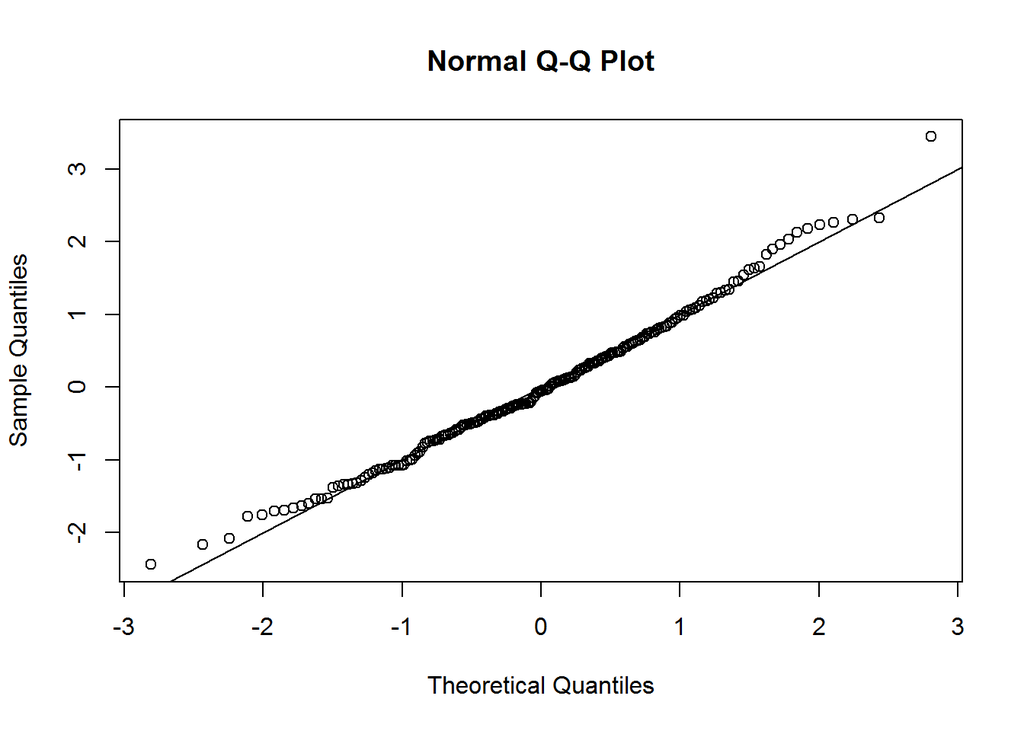

```r
#绘制QQ图
z.norm<-(x.norm - mean(x.norm))/sd(x.norm)
qqnorm(z.norm)
abline(0,1)
```

其次，通过QQ图来验证数据是否符合正态分布。

### 三.参数估计

1. 模拟估计
2. 矩估计
3. 极大似然估计

### 参考文献

- R语言实战
- 广义线性模型导论, 3rd Edition.
- Probability and Statistics for Economics
- [Fitting Distribution with R](https://cran.r-project.org/doc/contrib/Ricci-distributions-en.pdf)
- http://www.magesblog.com/2011/12/fitting-distributions-with-r.html